# How do individual interests influence voter turnout?

#### Group 19: Josie Panczyk, Leonardo Guzman, Nikhita Kalluri, Nicholas Wong

## Introduction

**Research question:** How do individual interests influence the likelihood of voting in elections?

This project aims to uncover how individual interests might serve as predictors of voting likelihood. By analyzing voter data in detail, we hope to develop a predictive model that forecasts voting behavior. We selected data from Iowa, a pivotal and highly contested state in the 2020 presidential election, for training this model. This dataset includes columns that describe potential voters’ interests, ranging from travel to NASCAR. Our goal is to use these interest categories to predict the variable “General_2020,” which indicates whether an individual voted. This model could offer insights into the relationship between hobbies, interests, personal preferences, and democratic participation. Such knowledge is crucial as it could illuminate how political campaigns might tailor their strategies to enhance voter turnout. For instance, if we discover a significant negative correlation between interest in NASCAR and voting, campaigns could then focus advertisements on NASCAR broadcasts, thereby potentially increasing voter turnout and strengthening democracy.

This project holds the potential to guide outreach and engagement strategies for organizations striving to boost voter participation. Understanding the intersection between voters’ interests and their political engagement could transform political campaigns, enabling them to target specific population segments with a noted voter disparity. Since this research suggests new ways for connecting with disenfranchised or indifferent voters, campaigns could design more effective communication and mobilization methods, thereby extending their reach. Additionally, this project will shed light on the impact of sociocultural differences on voter disparity, offering invaluable insights for politicians, educators, and government officials. This could help to cultivate a more involved and well-informed public.

```python
from pyspark.sql import SparkSession
spark = SparkSession.builder \
    .appName("MyApp") \
    .getOrCreate()
```

```
24/03/18 22:20:40 WARN SparkSession: Using an existing Spark session; only runtime SQL configurations will take effect.
```

## Readying the Data

First, we need to load our subset of data, which we saved as 'df_interests.' df_interests' contains all of the interest columns from the larger dataset, which contains data on all Iowa voters.

```python
df_interests = spark.read.parquet("gs://finalprojvoter/notebooks/df_interests.parquet")
```

### Missing Values

Now we check how many missing values there are per column. Here we can see that a substantial amount of data is missing.

```python
from pyspark.sql.functions import col, count, isnan, when


total_rows = df_interests.count()

missing_value_proportions = df_interests.select([
    (count(when(col(c).isNull() | isnan(c), c)) / total_rows).alias(c)
    for c in df_interests.columns
])

missing_value_proportions.show(vertical=True, truncate=10)
```

```
24/03/18 21:46:54 WARN package: Truncated the string representation of a plan since it was too large. This behavior can be adjusted by setting 'spark.sql.debug.maxToStringFields'.
[Stage 4:=============================>                             (1 + 1) / 2]
```

```
-RECORD 0----------------------------------------------------------------------------
 CommercialDataLL_Interest_in_Auto_Work_In_Household                    | 0.60183...
 CommercialDataLL_Interest_in_Automotive_Parts_Accessories_In_Household | 0.87003...
 CommercialDataLL_Interest_in_Aviation_In_Household                     | 0.98995...
 CommercialDataLL_Interest_in_BoardGames_Puzzles_In_Household           | 0.99441...
 CommercialDataLL_Interest_in_Boating_Sailing_In_Household              | 0.84003...
 CommercialDataLL_Interest_in_Camping_Hiking_In_Household               | 0.82510...
 CommercialDataLL_Interest_in_Cooking_General_In_Household              | 0.63922...
 CommercialDataLL_Interest_in_Cooking_Gourmet_In_Household              | 0.58289...
 CommercialDataLL_Interest_in_Crafts_In_Household                       | 0.55379...
 CommercialDataLL_Interest_in_Current_Affairs_Politics_In_Household     | 0.87825...
 CommercialDataLL_Interest_in_Education_Online_In_Household             | 0.94512...
 CommercialDataLL_Interest_in_Electronic_Gaming_In_Household            | 0.97572...
 CommercialDataLL_Interest_in_Exercise_Aerobic_In_Household             | 0.97575...
 CommercialDataLL_Interest_in_Exercise_Health_In_Household              | 0.45404...
 CommercialDataLL_Interest_in_Exercise_Running_Jogging_In_Household     | 0.96038...
 CommercialDataLL_Interest_in_Exercise_Walking_In_Household             | 0.81348...
 CommercialDataLL_Interest_in_Fishing_In_Household                      | 0.82732...
 CommercialDataLL_Interest_in_Food_Wines_In_Household                   | 0.94374...
 CommercialDataLL_Interest_in_Foods_Natural_In_Household                | 0.86812...
 CommercialDataLL_Interest_in_Gaming_Casino_In_Household                | 0.95088...
 CommercialDataLL_Interest_in_Gardening_In_Household                    | 0.45424...
 CommercialDataLL_Interest_in_Golf_In_Household                         | 0.81458...
 CommercialDataLL_Interest_in_History_Military_In_Household             | 0.96835...
 CommercialDataLL_Interest_in_Home_Furnishings_In_Household             | 0.40578...
 CommercialDataLL_Interest_in_Home_Improvement_In_Household             | 0.71505...
 CommercialDataLL_Interest_in_Home_Repair_In_Household                  | 0.96426...
 CommercialDataLL_Interest_in_House_Plants_In_Household                 | 0.99998...
 CommercialDataLL_Interest_in_Hunting_In_Household                      | 0.98438...
 CommercialDataLL_Interest_in_Motorcycling_In_Household                 | 0.92525...
 CommercialDataLL_Interest_in_Musical_Instruments_In_Household          | 0.98312...
 CommercialDataLL_Interest_in_Nascar_In_Household                       | 0.87102...
 CommercialDataLL_Interest_in_Photography_In_Household                  | 0.91592...
 CommercialDataLL_Interest_in_Photography_Video_In_Household            | 0.99546...
 CommercialDataLL_Interest_in_Religious_Inspirational_In_Household      | 0.82167...
 CommercialDataLL_Interest_in_Science_Space_In_Household                | 0.97333...
 CommercialDataLL_Interest_in_Scuba_Diving_In_Household                 | 0.99552...
 CommercialDataLL_Interest_in_Sewing_Knitting_In_Household              | 0.84193...
 CommercialDataLL_Interest_in_Shooting_In_Household                     | 0.78681...
 CommercialDataLL_Interest_in_Smoking_In_Household                      | 0.96013...
 CommercialDataLL_Interest_in_Snow_Skiing_In_Household                  | 0.96959...
 CommercialDataLL_Interest_in_SpectatorSports_Auto_Racing_In_Household  | 0.86841...
 CommercialDataLL_Interest_in_SpectatorSports_Baseball_In_Household     | 0.84491...
 CommercialDataLL_Interest_in_SpectatorSports_Basketball_In_Household   | 0.82802...
 CommercialDataLL_Interest_in_SpectatorSports_Football_In_Household     | 0.78210...
 CommercialDataLL_Interest_in_SpectatorSports_Hockey_In_Household       | 0.95966...
 CommercialDataLL_Interest_in_SpectatorSports_on_TV_In_Household        | 0.86930...
 CommercialDataLL_Interest_in_SpectatorSports_Soccer_In_Household       | 0.99681...
 CommercialDataLL_Interest_in_Sports_Leisure_In_Household               | 0.77254...
 CommercialDataLL_Interest_in_Sweepstakes_Contests_In_Household         | 0.78139...
 CommercialDataLL_Interest_in_Tennis_In_Household                       | 0.99089...
 CommercialDataLL_Interest_in_the_Arts_In_Household                     | 0.82234...
 CommercialDataLL_Interest_in_Theater_Performing_Arts_In_Household      | 0.90452...
 CommercialDataLL_Interest_in_Travel_Cruise_In_Household                | 0.83595...
 CommercialDataLL_Interest_in_Travel_Domestic_In_Household              | 0.68009...
 CommercialDataLL_Interest_in_Travel_International_In_Household         | 0.97047...
 CommercialDataLL_Interest_in_Woodworking_In_Household                  | 0.87591...
 General_2020                                                           | 0.20454...
```

In each interest column, 'Yes' indicates that voter has interest, and the missing value, null, indicates that the voter does not have interest. We need to binary encode the variables as such; with 0 indicating no and 'Yes' indicating yes.

```python
df_interests.select('CommercialDataLL_Interest_in_the_Arts_In_Household').distinct().show()
```

```
[Stage 7:=============================>                             (1 + 1) / 2]
```

```
+--------------------------------------------------+
|CommercialDataLL_Interest_in_the_Arts_In_Household|
+--------------------------------------------------+
|                                              null|
|                                               Yes|
+--------------------------------------------------+
```

Our target variable, 'General_2020', also contains two distinct values. 'Y' indicating that someone voted and 'null' indicating that someone did not vote. We will binary encode this the same way.

```python
df_interests.select('General_2020').distinct().show()
```

```
[Stage 10:=============================>                            (1 + 1) / 2]
```

```
+------------+
|General_2020|
+------------+
|        null|
|           Y|
+------------+
```

```python
from pyspark.sql.functions import when

columns_to_encode = [
    "CommercialDataLL_Interest_in_Auto_Work_In_Household",
    "CommercialDataLL_Interest_in_Automotive_Parts_Accessories_In_Household",
    "CommercialDataLL_Interest_in_Aviation_In_Household",
    "CommercialDataLL_Interest_in_BoardGames_Puzzles_In_Household",
    "CommercialDataLL_Interest_in_Boating_Sailing_In_Household",
    "CommercialDataLL_Interest_in_Camping_Hiking_In_Household",
    "CommercialDataLL_Interest_in_Cooking_General_In_Household",
    "CommercialDataLL_Interest_in_Cooking_Gourmet_In_Household",
    "CommercialDataLL_Interest_in_Crafts_In_Household",
    "CommercialDataLL_Interest_in_Current_Affairs_Politics_In_Household",
    "CommercialDataLL_Interest_in_Education_Online_In_Household",
    "CommercialDataLL_Interest_in_Electronic_Gaming_In_Household",
    "CommercialDataLL_Interest_in_Exercise_Aerobic_In_Household",
    "CommercialDataLL_Interest_in_Exercise_Health_In_Household",
    "CommercialDataLL_Interest_in_Exercise_Running_Jogging_In_Household",
    "CommercialDataLL_Interest_in_Exercise_Walking_In_Household",
    "CommercialDataLL_Interest_in_Fishing_In_Household",
    "CommercialDataLL_Interest_in_Food_Wines_In_Household",
    "CommercialDataLL_Interest_in_Foods_Natural_In_Household",
    "CommercialDataLL_Interest_in_Gaming_Casino_In_Household",
    "CommercialDataLL_Interest_in_Gardening_In_Household",
    "CommercialDataLL_Interest_in_Golf_In_Household",
    "CommercialDataLL_Interest_in_History_Military_In_Household",
    "CommercialDataLL_Interest_in_Home_Furnishings_In_Household",
    "CommercialDataLL_Interest_in_Home_Improvement_In_Household",
    "CommercialDataLL_Interest_in_Home_Repair_In_Household",
    "CommercialDataLL_Interest_in_House_Plants_In_Household",
    "CommercialDataLL_Interest_in_Hunting_In_Household",
    "CommercialDataLL_Interest_in_Motorcycling_In_Household",
    "CommercialDataLL_Interest_in_Musical_Instruments_In_Household",
    "CommercialDataLL_Interest_in_Nascar_In_Household",
    "CommercialDataLL_Interest_in_Photography_In_Household",
    "CommercialDataLL_Interest_in_Photography_Video_In_Household",
    "CommercialDataLL_Interest_in_Religious_Inspirational_In_Household",
    "CommercialDataLL_Interest_in_Science_Space_In_Household",
    "CommercialDataLL_Interest_in_Scuba_Diving_In_Household",
    "CommercialDataLL_Interest_in_Sewing_Knitting_In_Household",
    "CommercialDataLL_Interest_in_Shooting_In_Household",
    "CommercialDataLL_Interest_in_Smoking_In_Household",
    "CommercialDataLL_Interest_in_Snow_Skiing_In_Household",
    "CommercialDataLL_Interest_in_SpectatorSports_Auto_Racing_In_Household",
    "CommercialDataLL_Interest_in_SpectatorSports_Baseball_In_Household",
    "CommercialDataLL_Interest_in_SpectatorSports_Basketball_In_Household",
    "CommercialDataLL_Interest_in_SpectatorSports_Football_In_Household",
    "CommercialDataLL_Interest_in_SpectatorSports_Hockey_In_Household",
    "CommercialDataLL_Interest_in_SpectatorSports_on_TV_In_Household",
    "CommercialDataLL_Interest_in_SpectatorSports_Soccer_In_Household",
    "CommercialDataLL_Interest_in_Sports_Leisure_In_Household",
    "CommercialDataLL_Interest_in_Sweepstakes_Contests_In_Household",
    "CommercialDataLL_Interest_in_Tennis_In_Household",
    "CommercialDataLL_Interest_in_the_Arts_In_Household",
    "CommercialDataLL_Interest_in_Theater_Performing_Arts_In_Household",
    "CommercialDataLL_Interest_in_Travel_Cruise_In_Household",
    "CommercialDataLL_Interest_in_Travel_Domestic_In_Household",
    "CommercialDataLL_Interest_in_Travel_International_In_Household",
    "CommercialDataLL_Interest_in_Woodworking_In_Household"
]

df_encoded = df_interests

for column in columns_to_encode:
    df_encoded = df_encoded.withColumn(column, when(df_interests[column] == "Yes", 1.0).otherwise(0.0))
```

Now we save the encoded dataframe so we can easily access it when we train the model.

```python
df_encoded = df_encoded.withColumn('General_2020', when(df_interests['General_2020'] == 'Y', 1).otherwise(0))
df_encoded = df_encoded.withColumn("General_2020", df_encoded["General_2020"].cast("double"))
df_encoded.write.parquet("gs://finalprojvoter/notebooks/df_encoded.parquet", mode="overwrite")
```

```
24/03/18 22:06:15 WARN package: Truncated the string representation of a plan since it was too large. This behavior can be adjusted by setting 'spark.sql.debug.maxToStringFields'.
```

Here we can see that the dataset we are working with contains no missing values, yay!

```python
from pyspark.sql.functions import col, count, isnan, when

total_rows = df_encoded.count()

missing_value_proportions = df_encoded.select([
    (count(when(col(c).isNull() | isnan(c), c)) / total_rows).alias(c)
    for c in df_encoded.columns
])

missing_value_proportions.show(vertical=True, truncate=10)
```

```
[Stage 11:=============================>                            (1 + 1) / 2]
```

```
-RECORD 0---------------------------------------------------------------------
 CommercialDataLL_Interest_in_Auto_Work_In_Household                    | 0.0
 CommercialDataLL_Interest_in_Automotive_Parts_Accessories_In_Household | 0.0
 CommercialDataLL_Interest_in_Aviation_In_Household                     | 0.0
 CommercialDataLL_Interest_in_BoardGames_Puzzles_In_Household           | 0.0
 CommercialDataLL_Interest_in_Boating_Sailing_In_Household              | 0.0
 CommercialDataLL_Interest_in_Camping_Hiking_In_Household               | 0.0
 CommercialDataLL_Interest_in_Cooking_General_In_Household              | 0.0
 CommercialDataLL_Interest_in_Cooking_Gourmet_In_Household              | 0.0
 CommercialDataLL_Interest_in_Crafts_In_Household                       | 0.0
 CommercialDataLL_Interest_in_Current_Affairs_Politics_In_Household     | 0.0
 CommercialDataLL_Interest_in_Education_Online_In_Household             | 0.0
 CommercialDataLL_Interest_in_Electronic_Gaming_In_Household            | 0.0
 CommercialDataLL_Interest_in_Exercise_Aerobic_In_Household             | 0.0
 CommercialDataLL_Interest_in_Exercise_Health_In_Household              | 0.0
 CommercialDataLL_Interest_in_Exercise_Running_Jogging_In_Household     | 0.0
 CommercialDataLL_Interest_in_Exercise_Walking_In_Household             | 0.0
 CommercialDataLL_Interest_in_Fishing_In_Household                      | 0.0
 CommercialDataLL_Interest_in_Food_Wines_In_Household                   | 0.0
 CommercialDataLL_Interest_in_Foods_Natural_In_Household                | 0.0
 CommercialDataLL_Interest_in_Gaming_Casino_In_Household                | 0.0
 CommercialDataLL_Interest_in_Gardening_In_Household                    | 0.0
 CommercialDataLL_Interest_in_Golf_In_Household                         | 0.0
 CommercialDataLL_Interest_in_History_Military_In_Household             | 0.0
 CommercialDataLL_Interest_in_Home_Furnishings_In_Household             | 0.0
 CommercialDataLL_Interest_in_Home_Improvement_In_Household             | 0.0
 CommercialDataLL_Interest_in_Home_Repair_In_Household                  | 0.0
 CommercialDataLL_Interest_in_House_Plants_In_Household                 | 0.0
 CommercialDataLL_Interest_in_Hunting_In_Household                      | 0.0
 CommercialDataLL_Interest_in_Motorcycling_In_Household                 | 0.0
 CommercialDataLL_Interest_in_Musical_Instruments_In_Household          | 0.0
 CommercialDataLL_Interest_in_Nascar_In_Household                       | 0.0
 CommercialDataLL_Interest_in_Photography_In_Household                  | 0.0
 CommercialDataLL_Interest_in_Photography_Video_In_Household            | 0.0
 CommercialDataLL_Interest_in_Religious_Inspirational_In_Household      | 0.0
 CommercialDataLL_Interest_in_Science_Space_In_Household                | 0.0
 CommercialDataLL_Interest_in_Scuba_Diving_In_Household                 | 0.0
 CommercialDataLL_Interest_in_Sewing_Knitting_In_Household              | 0.0
 CommercialDataLL_Interest_in_Shooting_In_Household                     | 0.0
 CommercialDataLL_Interest_in_Smoking_In_Household                      | 0.0
 CommercialDataLL_Interest_in_Snow_Skiing_In_Household                  | 0.0
 CommercialDataLL_Interest_in_SpectatorSports_Auto_Racing_In_Household  | 0.0
 CommercialDataLL_Interest_in_SpectatorSports_Baseball_In_Household     | 0.0
 CommercialDataLL_Interest_in_SpectatorSports_Basketball_In_Household   | 0.0
 CommercialDataLL_Interest_in_SpectatorSports_Football_In_Household     | 0.0
 CommercialDataLL_Interest_in_SpectatorSports_Hockey_In_Household       | 0.0
 CommercialDataLL_Interest_in_SpectatorSports_on_TV_In_Household        | 0.0
 CommercialDataLL_Interest_in_SpectatorSports_Soccer_In_Household       | 0.0
 CommercialDataLL_Interest_in_Sports_Leisure_In_Household               | 0.0
 CommercialDataLL_Interest_in_Sweepstakes_Contests_In_Household         | 0.0
 CommercialDataLL_Interest_in_Tennis_In_Household                       | 0.0
 CommercialDataLL_Interest_in_the_Arts_In_Household                     | 0.0
 CommercialDataLL_Interest_in_Theater_Performing_Arts_In_Household      | 0.0
 CommercialDataLL_Interest_in_Travel_Cruise_In_Household                | 0.0
 CommercialDataLL_Interest_in_Travel_Domestic_In_Household              | 0.0
 CommercialDataLL_Interest_in_Travel_International_In_Household         | 0.0
 CommercialDataLL_Interest_in_Woodworking_In_Household                  | 0.0
 General_2020                                                           | 0.0
```

Here, we see that all of our variables are of the type 'double', which is exactly what we need for model training.

```python
df_encoded.printSchema()
```

```
root
 |-- CommercialDataLL_Interest_in_Auto_Work_In_Household: double (nullable = false)
 |-- CommercialDataLL_Interest_in_Automotive_Parts_Accessories_In_Household: double (nullable = false)
 |-- CommercialDataLL_Interest_in_Aviation_In_Household: double (nullable = false)
 |-- CommercialDataLL_Interest_in_BoardGames_Puzzles_In_Household: double (nullable = false)
 |-- CommercialDataLL_Interest_in_Boating_Sailing_In_Household: double (nullable = false)
 |-- CommercialDataLL_Interest_in_Camping_Hiking_In_Household: double (nullable = false)
 |-- CommercialDataLL_Interest_in_Cooking_General_In_Household: double (nullable = false)
 |-- CommercialDataLL_Interest_in_Cooking_Gourmet_In_Household: double (nullable = false)
 |-- CommercialDataLL_Interest_in_Crafts_In_Household: double (nullable = false)
 |-- CommercialDataLL_Interest_in_Current_Affairs_Politics_In_Household: double (nullable = false)
 |-- CommercialDataLL_Interest_in_Education_Online_In_Household: double (nullable = false)
 |-- CommercialDataLL_Interest_in_Electronic_Gaming_In_Household: double (nullable = false)
 |-- CommercialDataLL_Interest_in_Exercise_Aerobic_In_Household: double (nullable = false)
 |-- CommercialDataLL_Interest_in_Exercise_Health_In_Household: double (nullable = false)
 |-- CommercialDataLL_Interest_in_Exercise_Running_Jogging_In_Household: double (nullable = false)
 |-- CommercialDataLL_Interest_in_Exercise_Walking_In_Household: double (nullable = false)
 |-- CommercialDataLL_Interest_in_Fishing_In_Household: double (nullable = false)
 |-- CommercialDataLL_Interest_in_Food_Wines_In_Household: double (nullable = false)
 |-- CommercialDataLL_Interest_in_Foods_Natural_In_Household: double (nullable = false)
 |-- CommercialDataLL_Interest_in_Gaming_Casino_In_Household: double (nullable = false)
 |-- CommercialDataLL_Interest_in_Gardening_In_Household: double (nullable = false)
 |-- CommercialDataLL_Interest_in_Golf_In_Household: double (nullable = false)
 |-- CommercialDataLL_Interest_in_History_Military_In_Household: double (nullable = false)
 |-- CommercialDataLL_Interest_in_Home_Furnishings_In_Household: double (nullable = false)
 |-- CommercialDataLL_Interest_in_Home_Improvement_In_Household: double (nullable = false)
 |-- CommercialDataLL_Interest_in_Home_Repair_In_Household: double (nullable = false)
 |-- CommercialDataLL_Interest_in_House_Plants_In_Household: double (nullable = false)
 |-- CommercialDataLL_Interest_in_Hunting_In_Household: double (nullable = false)
 |-- CommercialDataLL_Interest_in_Motorcycling_In_Household: double (nullable = false)
 |-- CommercialDataLL_Interest_in_Musical_Instruments_In_Household: double (nullable = false)
 |-- CommercialDataLL_Interest_in_Nascar_In_Household: double (nullable = false)
 |-- CommercialDataLL_Interest_in_Photography_In_Household: double (nullable = false)
 |-- CommercialDataLL_Interest_in_Photography_Video_In_Household: double (nullable = false)
 |-- CommercialDataLL_Interest_in_Religious_Inspirational_In_Household: double (nullable = false)
 |-- CommercialDataLL_Interest_in_Science_Space_In_Household: double (nullable = false)
 |-- CommercialDataLL_Interest_in_Scuba_Diving_In_Household: double (nullable = false)
 |-- CommercialDataLL_Interest_in_Sewing_Knitting_In_Household: double (nullable = false)
 |-- CommercialDataLL_Interest_in_Shooting_In_Household: double (nullable = false)
 |-- CommercialDataLL_Interest_in_Smoking_In_Household: double (nullable = false)
 |-- CommercialDataLL_Interest_in_Snow_Skiing_In_Household: double (nullable = false)
 |-- CommercialDataLL_Interest_in_SpectatorSports_Auto_Racing_In_Household: double (nullable = false)
 |-- CommercialDataLL_Interest_in_SpectatorSports_Baseball_In_Household: double (nullable = false)
 |-- CommercialDataLL_Interest_in_SpectatorSports_Basketball_In_Household: double (nullable = false)
 |-- CommercialDataLL_Interest_in_SpectatorSports_Football_In_Household: double (nullable = false)
 |-- CommercialDataLL_Interest_in_SpectatorSports_Hockey_In_Household: double (nullable = false)
 |-- CommercialDataLL_Interest_in_SpectatorSports_on_TV_In_Household: double (nullable = false)
 |-- CommercialDataLL_Interest_in_SpectatorSports_Soccer_In_Household: double (nullable = false)
 |-- CommercialDataLL_Interest_in_Sports_Leisure_In_Household: double (nullable = false)
 |-- CommercialDataLL_Interest_in_Sweepstakes_Contests_In_Household: double (nullable = false)
 |-- CommercialDataLL_Interest_in_Tennis_In_Household: double (nullable = false)
 |-- CommercialDataLL_Interest_in_the_Arts_In_Household: double (nullable = false)
 |-- CommercialDataLL_Interest_in_Theater_Performing_Arts_In_Household: double (nullable = false)
 |-- CommercialDataLL_Interest_in_Travel_Cruise_In_Household: double (nullable = false)
 |-- CommercialDataLL_Interest_in_Travel_Domestic_In_Household: double (nullable = false)
 |-- CommercialDataLL_Interest_in_Travel_International_In_Household: double (nullable = false)
 |-- CommercialDataLL_Interest_in_Woodworking_In_Household: double (nullable = false)
 |-- General_2020: double (nullable = false)
```

## Exploratory Data Analysis

Now that our data is cleaned, it is time to do some exploratory data analysis (EDA).

```python
df_encoded = spark.read.parquet("gs://finalprojvoter/notebooks/df_encoded.parquet")
```

To begin our data exploration, we conducted exploratory data analysis on the columns of interest, which included surveyed interests and voting data from the 2020 general election. This allowed us to understand the data distribution and identify any patterns and strong correlations.

We begin this process by constructing a correlation plot of the columns to find the highest positive and negative correlations:

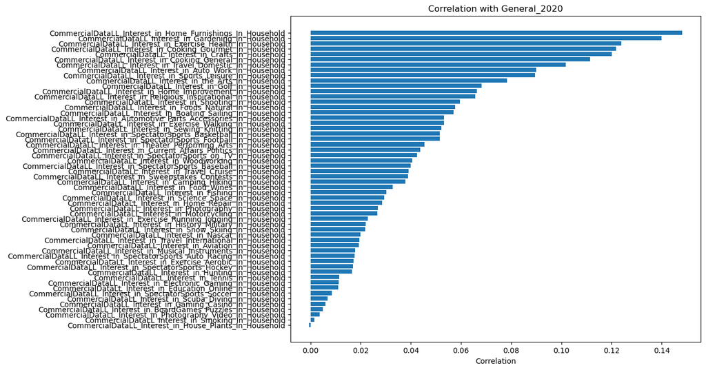

```python
from pyspark.sql.functions import corr
import matplotlib.pyplot as plt

feature_columns = [
    "CommercialDataLL_Interest_in_Auto_Work_In_Household",
    "CommercialDataLL_Interest_in_Automotive_Parts_Accessories_In_Household",
    "CommercialDataLL_Interest_in_Aviation_In_Household",
    "CommercialDataLL_Interest_in_BoardGames_Puzzles_In_Household",
    "CommercialDataLL_Interest_in_Boating_Sailing_In_Household",
    "CommercialDataLL_Interest_in_Camping_Hiking_In_Household",
    "CommercialDataLL_Interest_in_Cooking_General_In_Household",
    "CommercialDataLL_Interest_in_Cooking_Gourmet_In_Household",
    "CommercialDataLL_Interest_in_Crafts_In_Household",
    "CommercialDataLL_Interest_in_Current_Affairs_Politics_In_Household",
    "CommercialDataLL_Interest_in_Education_Online_In_Household",
    "CommercialDataLL_Interest_in_Electronic_Gaming_In_Household",
    "CommercialDataLL_Interest_in_Exercise_Aerobic_In_Household",
    "CommercialDataLL_Interest_in_Exercise_Health_In_Household",
    "CommercialDataLL_Interest_in_Exercise_Running_Jogging_In_Household",
    "CommercialDataLL_Interest_in_Exercise_Walking_In_Household",
    "CommercialDataLL_Interest_in_Fishing_In_Household",
    "CommercialDataLL_Interest_in_Food_Wines_In_Household",
    "CommercialDataLL_Interest_in_Foods_Natural_In_Household",
    "CommercialDataLL_Interest_in_Gaming_Casino_In_Household",
    "CommercialDataLL_Interest_in_Gardening_In_Household",
    "CommercialDataLL_Interest_in_Golf_In_Household",
    "CommercialDataLL_Interest_in_History_Military_In_Household",
    "CommercialDataLL_Interest_in_Home_Furnishings_In_Household",
    "CommercialDataLL_Interest_in_Home_Improvement_In_Household",
    "CommercialDataLL_Interest_in_Home_Repair_In_Household",
    "CommercialDataLL_Interest_in_House_Plants_In_Household",
    "CommercialDataLL_Interest_in_Hunting_In_Household",
    "CommercialDataLL_Interest_in_Motorcycling_In_Household",
    "CommercialDataLL_Interest_in_Musical_Instruments_In_Household",
    "CommercialDataLL_Interest_in_Nascar_In_Household",
    "CommercialDataLL_Interest_in_Photography_In_Household",
    "CommercialDataLL_Interest_in_Photography_Video_In_Household",
    "CommercialDataLL_Interest_in_Religious_Inspirational_In_Household",
    "CommercialDataLL_Interest_in_Science_Space_In_Household",
    "CommercialDataLL_Interest_in_Scuba_Diving_In_Household",
    "CommercialDataLL_Interest_in_Sewing_Knitting_In_Household",
    "CommercialDataLL_Interest_in_Shooting_In_Household",
    "CommercialDataLL_Interest_in_Smoking_In_Household",
    "CommercialDataLL_Interest_in_Snow_Skiing_In_Household",
    "CommercialDataLL_Interest_in_SpectatorSports_Auto_Racing_In_Household",
    "CommercialDataLL_Interest_in_SpectatorSports_Baseball_In_Household",
    "CommercialDataLL_Interest_in_SpectatorSports_Basketball_In_Household",
    "CommercialDataLL_Interest_in_SpectatorSports_Football_In_Household",
    "CommercialDataLL_Interest_in_SpectatorSports_Hockey_In_Household",
    "CommercialDataLL_Interest_in_SpectatorSports_on_TV_In_Household",
    "CommercialDataLL_Interest_in_SpectatorSports_Soccer_In_Household",
    "CommercialDataLL_Interest_in_Sports_Leisure_In_Household",
    "CommercialDataLL_Interest_in_Sweepstakes_Contests_In_Household",
    "CommercialDataLL_Interest_in_Tennis_In_Household",
    "CommercialDataLL_Interest_in_the_Arts_In_Household",
    "CommercialDataLL_Interest_in_Theater_Performing_Arts_In_Household",
    "CommercialDataLL_Interest_in_Travel_Cruise_In_Household",
    "CommercialDataLL_Interest_in_Travel_Domestic_In_Household",
    "CommercialDataLL_Interest_in_Travel_International_In_Household",
    "CommercialDataLL_Interest_in_Woodworking_In_Household"
]


correlations = []

for col in feature_columns:
    correlation = df_encoded.stat.corr('General_2020', col)
    correlations.append((col, correlation))

correlations.sort(key=lambda x: x[1], reverse=True)

labels, values = zip(*correlations)

plt.figure(figsize=(10, 8))
plt.barh(labels, values)
plt.xlabel('Correlation')
plt.title('Correlation with General_2020')
plt.gca().invert_yaxis()
plt.show()
```

Through this exploration of the data, we could see patterns between certain variables and understand relationships within the dataset. This also informs the use of a logistic regression model to determine the coefficients for understanding the relationship between predictor variables and the outcome variable.

```python
sorted_correlations = sorted(correlations, key=lambda x: x[1])

top_5_positive_correlations = sorted_correlations[-5:]

top_5_negative_correlations = sorted_correlations[:5]

print("Top 5 Positive Correlations:")
for col, corr in reversed(top_5_positive_correlations):
    print(f"{col}: {corr}")

print("\nTop 5 Negative Correlations:")
for col, corr in top_5_negative_correlations:
    print(f"{col}: {corr}")
```

```
Top 5 Positive Correlations:
CommercialDataLL_Interest_in_Home_Furnishings_In_Household: 0.14816807816082658
CommercialDataLL_Interest_in_Gardening_In_Household: 0.14001310445155998
CommercialDataLL_Interest_in_Exercise_Health_In_Household: 0.12383227645766526
CommercialDataLL_Interest_in_Cooking_Gourmet_In_Household: 0.1217579260748068
CommercialDataLL_Interest_in_Crafts_In_Household: 0.12004417255671095

Top 5 Negative Correlations:
CommercialDataLL_Interest_in_House_Plants_In_Household: -0.00043981029355264384
CommercialDataLL_Interest_in_Smoking_In_Household: 0.001638268192159116
CommercialDataLL_Interest_in_Photography_Video_In_Household: 0.0037023288364194744
CommercialDataLL_Interest_in_BoardGames_Puzzles_In_Household: 0.0050431347572012265
CommercialDataLL_Interest_in_Gaming_Casino_In_Household: 0.0059167705299645
```

Starting with the positive correlations, the highest is an interest in home furnishings, suggesting that those who are invested in the aesthetics of their living space might be more likely to participate in voting. This could potentially reflect a demographic that is more settled and possibly may have a greater involvement in their community. Gardening follows closely, which may indicate a connection to homeownership or a lifestyle that values sustainability and the environment. This shows that these factors may translate into civic engagement. Health and exercise come next, potentially indicating a connection between the role of personal well-being and voting. Cooking gourmet foods and interest in crafts are also positively correlated, possibly pointing to a segment of the population that values culture and creativity, traits that could correlate with voting.

```
Number of observations within each group:
```

```
+------------+-------+
|General_2020|  count|
+------------+-------+
|         1.0|1670731|
|         0.0| 429627|
+------------+-------+
```

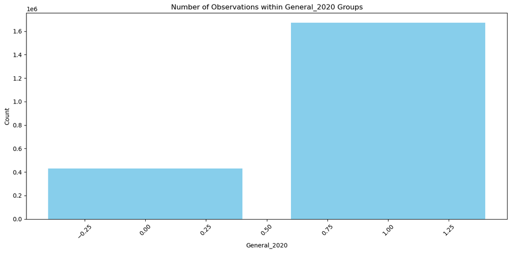

```python
import seaborn as sns
import matplotlib.pyplot as plt

General_2020_counts = df_encoded.groupBy("General_2020").count().orderBy("count", ascending=False)

General_2020_counts = df_encoded.groupBy("General_2020").count().orderBy("count", ascending=False)

print("Number of observations within each group:")
General_2020_counts.show()

general_2020_counts_pd = General_2020_counts.toPandas()

# Plotting the histogram
plt.figure(figsize=(12, 6))
plt.bar(general_2020_counts_pd["General_2020"], general_2020_counts_pd["count"], color='skyblue')
plt.xlabel("General_2020")
plt.ylabel("Count")
plt.title("Number of Observations within General_2020 Groups")
plt.xticks(rotation=45)
plt.tight_layout()
plt.show()
```

After creating the correlation plot, we examined the distribution of the outcome variable (General_2020) by constructing a histogram of the counts of people who voted and did not vote. We found that the number of people who did not vote (429,627) was much lower than those who did (1,670,731) in the 2020 election. However, it is important to note when creating recommendations for political campaigns that this election had the highest historical turnout.

## The Model

In the file 'LogisticModel.ipynb' we built a regularized logistic model and went through the tuning and cross validation process. Here, we are loading that model...

```python
from pyspark.ml import PipelineModel

loaded_model = PipelineModel.load('gs://finalprojvoter/notebooks/LogisticModelTuned')
logistic_regression_model = loaded_model.stages[-1]
```

### Interpretation of Model

```python
from pyspark.sql.functions import monotonically_increasing_id, row_number
from pyspark.sql import Window
import pyspark.sql.functions as F

interests_list = [
    "Auto_Work_In_Household",
    "Automotive_Parts_Accessories_In_Household",
    "Aviation_In_Household",
    "BoardGames_Puzzles_In_Household",
    "Boating_Sailing_In_Household",
    "Camping_Hiking_In_Household",
    "Cooking_General_In_Household",
    "Cooking_Gourmet_In_Household",
    "Crafts_In_Household",
    "Current_Affairs_Politics_In_Household",
    "Education_Online_In_Household",
    "Electronic_Gaming_In_Household",
    "Exercise_Aerobic_In_Household",
    "Exercise_Health_In_Household",
    "Exercise_Running_Jogging_In_Household",
    "Exercise_Walking_In_Household",
    "Fishing_In_Household",
    "Food_Wines_In_Household",
    "Foods_Natural_In_Household",
    "Gaming_Casino_In_Household",
    "Gardening_In_Household",
    "Golf_In_Household",
    "History_Military_In_Household",
    "Home_Furnishings_In_Household",
    "Home_Improvement_In_Household",
    "Home_Repair_In_Household",
    "House_Plants_In_Household",
    "Hunting_In_Household",
    "Motorcycling_In_Household",
    "Musical_Instruments_In_Household",
    "Nascar_In_Household",
    "Photography_In_Household",
    "Photography_Video_In_Household",
    "Religious_Inspirational_In_Household",
    "Science_Space_In_Household",
    "Scuba_Diving_In_Household",
    "Sewing_Knitting_In_Household",
    "Shooting_In_Household",
    "Smoking_In_Household",
    "Snow_Skiing_In_Household",
    "SpectatorSports_Auto_Racing_In_Household",
    "SpectatorSports_Baseball_In_Household",
    "SpectatorSports_Basketball_In_Household",
    "SpectatorSports_Football_In_Household",
    "SpectatorSports_Hockey_In_Household",
    "SpectatorSports_on_TV_In_Household",
    "SpectatorSports_Soccer_In_Household",
    "Sports_Leisure_In_Household",
    "Sweepstakes_Contests_In_Household",
    "Tennis_In_Household",
    "Arts_In_Household",
    "Theater_Performing_Arts_In_Household",
    "Travel_Cruise_In_Household",
    "Travel_Domestic_In_Household",
    "Travel_International_In_Household",
    "Woodworking_In_Household"
]

interest_df = sqlContext.createDataFrame([(l,) for l in interests_list], ['Interests'])

weights = logistic_regression_model.coefficients
weights = [(float(w),) for w in weights]
weightsDF = spark.createDataFrame(weights, ["Feature Weight"])

weightsDF = weightsDF.withColumn("Odds Ratio", F.exp("Feature Weight"))
weightsDF = weightsDF.withColumn("row_idx", row_number().over(Window.orderBy(monotonically_increasing_id())))

interest_df = interest_df.withColumn("row_idx", row_number().over(Window.orderBy(monotonically_increasing_id())))
final_df = weightsDF.join(interest_df, weightsDF.row_idx == interest_df.row_idx).\
             drop("row_idx")

final_df = final_df.select("Interests", "Feature Weight", "Odds Ratio")
final_df.show(60)
```

[output not shown]

```
+--------------------+--------------------+------------------+
|           Interests|      Feature Weight|        Odds Ratio|
+--------------------+--------------------+------------------+
|Auto_Work_In_Hous...|0.014099190205222992|1.0141990525616194|
|Automotive_Parts_...| 0.04853194991738041|1.0497289100364982|
|Aviation_In_House...|   0.160523380042077|1.1741252239168536|
|BoardGames_Puzzle...|-0.05488406390114...|0.9465948861103424|
|Boating_Sailing_I...| 0.08789525095569693|  1.09187374330666|
|Camping_Hiking_In...|-0.08920282754074402|0.9146600365132523|
|Cooking_General_I...| 0.11994391312914514|1.1274336155824431|
|Cooking_Gourmet_I...|  0.0610676187017073|1.0629707884618138|
| Crafts_In_Household|0.011999967686350744|1.0120722561623292|
|Current_Affairs_P...| 0.04129850647230996|1.0421631515644898|
|Education_Online_...|-0.13658605364297102|0.8723312497477046|
|Electronic_Gaming...|-0.08818104130879213|0.9155951011822263|
|Exercise_Aerobic_...|-0.13512746383238508| 0.873604551606857|
|Exercise_Health_I...| 0.15970324835776262| 1.173162681379135|
|Exercise_Running_...| 0.01664688582593583| 1.016786217301113|
|Exercise_Walking_...| 0.04977257026899841| 1.051032033259426|
|Fishing_In_Household|-0.13341360528931182|  0.87510306998836|
|Food_Wines_In_Hou...| 0.10357652588491731|1.1091306673233048|
|Foods_Natural_In_...| -0.0512314817637449| 0.950058723807533|
|Gaming_Casino_In_...|-0.13220839337642884|0.8761583904479644|
|Gardening_In_Hous...| 0.19258490359796046| 1.212379434713876|
|   Golf_In_Household| 0.13368795922946655|1.1430360901281538|
|History_Military_...|-0.00885205600135...|0.9911870080955354|
|Home_Furnishings_...| 0.27873494280161626|1.3214570357460658|
|Home_Improvement_...|-0.03409081903527679|0.9664837255319966|
|Home_Repair_In_Ho...|0.026558174264104714|1.0269139854894562|
|House_Plants_In_H...|-0.46322614156075476|0.6292503167682781|
|Hunting_In_Household|-0.03464099932707...|0.9659521314835587|
|Motorcycling_In_H...|-0.03336678399189723|0.9671837470075967|
|Musical_Instrumen...| 0.06694940394053926|1.0692413774056597|
| Nascar_In_Household|-0.05955372103175265|0.9421849170858092|
|Photography_In_Ho...|-0.03217167234131059|0.9683403305574796|
|Photography_Video...| -0.1352498210714397|0.8734976663051254|
|Religious_Inspira...| 0.07935078428803675| 1.082584008933142|
|Science_Space_In_...| 0.17621818392256253|1.1926982578483272|
|Scuba_Diving_In_H...|-0.02188756280346...|0.9783502318245266|
|Sewing_Knitting_I...|-0.00409298045696...|0.9959153843712905|
|Shooting_In_House...|-3.61941797477486...| 0.999638123695553|
|Smoking_In_Household|-0.19623355089692276|0.8218202754004993|
|Snow_Skiing_In_Ho...|0.030845430915649064|1.0313260804379514|
|SpectatorSports_A...| -0.1300771201114007|0.8780277147142825|
|SpectatorSports_B...|-0.07552255908691433|0.9272588121859141|
|SpectatorSports_B...| 0.04481504616118941| 1.045834410930641|
|SpectatorSports_F...|4.811423739856994E-4|1.0004812581415439|
|SpectatorSports_H...|-0.03777788916249449|0.9629267936174032|
|SpectatorSports_o...|0.057872438486375286|1.0595798254828666|
|SpectatorSports_S...| 0.03551960083963591|1.0361579574949862|
|Sports_Leisure_In...| 0.21266130156519428| 1.236965621965258|
|Sweepstakes_Conte...|-0.12246902092022179|0.8847333127428251|
| Tennis_In_Household| 0.01138806363586478|1.0114531544841288|
|   Arts_In_Household| 0.10843618165236929|1.1145337785645402|
|Theater_Performin...| 0.07128989917274271| 1.073892501294673|
|Travel_Cruise_In_...|-0.05445625136705521|0.9469999379042684|
|Travel_Domestic_I...| 0.13510249123800352|1.1446540953548556|
|Travel_Internatio...|-0.04641689152703...|0.9546438962696312|
|Woodworking_In_Ho...|-7.73367552003775...|0.9992269314196048|
+--------------------+--------------------+------------------+
```

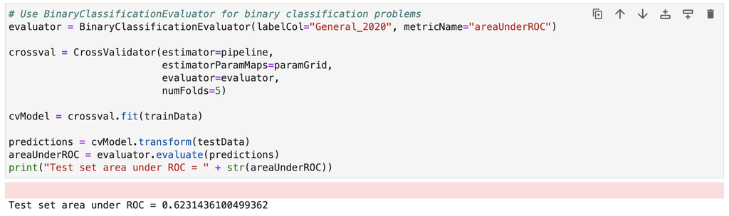

We included an image of the AUC because connection errors prevented us from running the code inside this file. For complete documentation of the model code please see the included file called "LogisticModel.ipynb".

In logistic regression, the role of weights differs from their role in linear regression because the output of a logistic regression model must fall between 0 and 1, not affecting the outcome variable in a linear way. To gain a clearer understanding of how a feature variable's unit change affects the outcome, we can convert the weights into odds ratios through algebraic manipulation. The odds ratio is a measure that tells how the probability of a certain event occurring changes with a one-unit increase in a predictor variable, while other variables are held constant. For instance, if the odds ratio for someone with an interest in automotive parts is 1.049, it indicates that, keeping all other variables constant, their odds of voting versus not voting increase by a factor of 1.049.

## What Concrete Actions Can We Take?

To enhance our political campaign’s success, focusing on converting non-voters into voters is a great strategy. Non-voters often lack strong opinions about elections, making them potentially more receptive to new perspectives compared to habitual voters who already have firm beliefs. Thus, emphasizing the importance of voting and persuading non-voters to participate could significantly increase support for our campaign, especially since our efforts would directly contribute to their decision to vote.

To boost voter turnout, particularly among these less represented groups, strategies could include improving access to voting through better infrastructure in rural areas, educational initiatives to address political skepticism, and targeted communication that aligns with the specific interests of these groups. For instance, emphasizing sustainable living for those interested in natural foods or land conservation for hunting and shooting enthusiasts could make the campaign more relevant to their values.

Additionally, community events that cater to specific interests, such as board game conventions or hunting expositions, could serve as platforms for voter engagement and education. Making voting more convenient through transportation services, extended voting periods, and promoting absentee or mail-in options are crucial, especially for those in remote areas. Finally, leveraging social media to target messages to specific groups could further increase voter participation.

By adopting these strategies, not only do we stand to gain votes from previously unengaged segments of the population, but we also reinforce the democratic process by encouraging broader participation in elections.